# Séance 3 : Importer des données

CSV, URL, paquets, API, bases de données : monter le dossier Tesla

Thierry Warin, PhD

HEC Montréal

## Plan · La séance

1. Une question, cinq sources
2. Le fichier CSV local — et ses pièges
3. Une URL : lire un fichier en ligne
4. Les paquets qui parlent aux sources
5. Les API : demander des données à un serveur
6. Les bases de données : SQL depuis Python
7. Sauvegarder, mettre en cache, documenter

## À quoi sert la séance 3

### La stratégie

- Traduire « Tesla est-elle bonne pour l’environnement ? » en **liste de données** à réunir
- Savoir d’où vient chaque chiffre : producteur, unité, date, licence
- Juger si une source est assez fiable pour une décision

### Le Python

- `pd.read_csv` avec `sep`, `decimal`, `encoding`, `usecols`, `dtype`, `nrows`
- `requests.get` : code de statut, JSON, paramètres, en-têtes
- `pd.read_sql` sur SQLite, et DuckDB sur un fichier CSV

### La méthode

- Télécharger **une fois**, relire en local ensuite (le cache)
- Ne jamais écrire une clé d’API ou un courriel dans le code
- Tenir une **fiche de provenance** pour chaque source

# Une question, cinq sources

## Ce qu’il faudrait réunir

« Tesla est-elle bonne pour l’environnement ? » À la séance 1, nous avons écrit les questions précises. Chacune appelle **une source différente**, servie d’une **façon différente** :

| Ce qu’on veut savoir | Source | Comment on l’obtient |
| --- | --- | --- |
| Taille et rentabilité de Tesla, Ford, GM | SEC, via `data/entreprises.csv` | **Fichier CSV** local |
| Émissions de CO₂ par habitant, par pays | Our World in Data | **URL** d’un fichier en ligne |
| Ce que le marché pense de Tesla | Yahoo Finance | **Paquet** `yfinance` |
| Part de l’électricité renouvelable | Banque mondiale | **API** web (et paquet `wbgapi`) |
| Les déclarations financières détaillées | SEC EDGAR | **API** avec un en-tête obligatoire |
| Toutes les données du cours, réunies | `data/strategie.db` | **Base de données** SQL |

Une voiture électrique roule avec l’électricité **du pays où elle roule**. La question environnementale est donc aussi une question de **pays** — d’où les sources internationales.

# Le fichier CSV local

## `read_csv` : le cas simple

```python
import pandas as pd

entreprises = pd.read_csv("data/entreprises.csv")
print(entreprises.shape)
entreprises.head(3)
```

```
(480, 12)
```

|  | ticker | entreprise | cik | secteur | ... | actifs_totaux | capitaux_propres | rd | investissements |
| --- | --- | --- | --- | --- | --- | --- | --- | --- | --- |
| 0 | TSLA | Tesla | 1318605 | Automobile | ... | 386.1 | 207.0 | 93.0 | 40.2 |
| 1 | TSLA | Tesla | 1318605 | Automobile | ... | 713.4 | 224.0 | 209.0 | 184.2 |
| 2 | TSLA | Tesla | 1318605 | Automobile | ... | 1114.2 | 124.7 | 274.0 | 239.2 |

3 rows × 12 columns

CSV veut dire *comma-separated values* : du texte, une ligne par observation, des virgules entre les colonnes. C’est le format le plus répandu — et le moins normalisé.

## Le même fichier, « à la française »

Excel en français enregistre un CSV avec **`;`** entre les colonnes, **`,`** pour la décimale, et un encodage Windows. Ouvrons `data/entreprises_fr.csv` comme si de rien n’était :

```python
mal = pd.read_csv("data/entreprises_fr.csv", encoding="cp1252")
print(mal.shape)
mal.head(2)
```

```
(480, 1)
```

|  |  |  |  |  |  | ticker;entreprise;cik;secteur;pays_siege;annee;chiffre_affaires;resultat_net;actifs_totaux;capitaux_propres;rd;investissements |
| --- | --- | --- | --- | --- | --- | --- |
| TSLA;Tesla;1318605;Automobile;USA;2010;116 | 7;-154 | 3;386 | 1;207 | 0;93 | 0;40 | 2.0 |
| TSLA;Tesla;1318605;Automobile;USA;2011;204 | 2;-254 | 4;713 | 4;224 | 0;209 | 0;184 | 2.0 |

Aucune erreur, et pourtant **une seule colonne** : pandas a cherché des virgules, n’a trouvé que des points-virgules, et a tout mis dans la même case. Toujours vérifier `.shape` après un import.

## Sans l’encodage : une erreur, cette fois

```python
try:
    pd.read_csv("data/entreprises_fr.csv", sep=";")
except UnicodeDecodeError as erreur:
    print(type(erreur).__name__, ":", erreur)
```

```
UnicodeDecodeError : 'utf-8' codec can't decode byte 0xe9 in position 13: invalid continuation byte
```

Le caractère `é` de « Énergie » n’est pas écrit de la même façon en UTF-8 (le standard du web) et en Windows-1252 (le défaut d’Excel sous Windows). L’octet `0xe9`, c’est un `é` en Windows-1252.

## Les trois options qui règlent tout

```python
bon = pd.read_csv(
    "data/entreprises_fr.csv",
    sep=";",            # séparateur de colonnes
    decimal=",",        # séparateur décimal
    encoding="cp1252",  # encodage Windows (« latin » d'Excel)
)
print(bon.shape)
print(bon["chiffre_affaires"].dtype)
```

```
(480, 12)
float64
```

Si `decimal=","` manque, `"96773,0"` reste du **texte** (`object`) : impossible d’en faire la moyenne. Le type d’une colonne dit si l’import a réussi.

## Lire moins, lire juste : `usecols`, `dtype`, `nrows`

```python
apercu = pd.read_csv("data/entreprises.csv", nrows=5)          # un coup d'œil
leger = pd.read_csv(
    "data/entreprises.csv",
    usecols=["ticker", "annee", "chiffre_affaires", "resultat_net"],   # 4 colonnes sur 12
    dtype={"ticker": "category", "annee": "int16"},                  # types imposés
)
print(apercu.shape, leger.shape)
print(leger.dtypes)
```

```
(5, 12) (480, 4)
ticker              category
annee                  int16
chiffre_affaires     float64
resultat_net         float64
dtype: object
```

Sur un fichier de 50 000 lignes, c’est un détail. Sur 50 millions, `usecols` décide si l’ordinateur tient le coup.

## Excel : aller-retour

```python
from pathlib import Path

Path("sorties").mkdir(exist_ok=True)
auto = entreprises[entreprises["secteur"] == "Automobile"]
auto.to_excel("sorties/automobile.xlsx", sheet_name="auto", index=False)

relu = pd.read_excel("sorties/automobile.xlsx", sheet_name="auto")
print(relu.shape)
relu.tail(3)
```

```
(45, 12)
```

|  | ticker | entreprise | cik | secteur | ... | actifs_totaux | capitaux_propres | rd | investissements |
| --- | --- | --- | --- | --- | --- | --- | --- | --- | --- |
| 42 | GM | General Motors | 1467858 | Automobile | ... | 264037.0 | 67792.0 | NaN | 9238.0 |
| 43 | GM | General Motors | 1467858 | Automobile | ... | 273064.0 | 64286.0 | NaN | 10970.0 |
| 44 | GM | General Motors | 1467858 | Automobile | ... | 279761.0 | 63072.0 | NaN | 10830.0 |

3 rows × 12 columns

`read_excel` demande le paquet `openpyxl`, installé par `requirements.txt`. `index=False` évite une colonne de numéros de ligne inutile dans le classeur.

# Une URL : lire un fichier en ligne

## Une règle avant d’aller en ligne : télécharger une fois

Le réseau de la salle est lent, les serveurs changent leurs fichiers, et certains limitent le nombre de requêtes. On télécharge **une fois**, on garde une copie, on relit la copie.

```python
from pathlib import Path

CACHE = Path("data/cache")
CACHE.mkdir(parents=True, exist_ok=True)

def charger(nom, telecharger):
    """Relit data/cache/<nom>.parquet s'il existe ; sinon télécharge, enregistre, renvoie."""
    fichier = CACHE / f"{nom}.parquet"
    if fichier.exists():
        return pd.read_parquet(fichier)
    df = telecharger()
    df.to_parquet(fichier)
    return df
```

`telecharger` est une **fonction** que l’on passe à `charger` ; elle ne s’exécute que si la copie locale manque. Pour la supprimer et forcer un nouveau téléchargement : effacez le fichier.

## Our World in Data : le CO₂ de tous les pays

```python
URL_CO2 = "https://raw.githubusercontent.com/owid/co2-data/master/owid-co2-data.csv"

co2 = charger("owid_co2", lambda: pd.read_csv(
    URL_CO2, usecols=["country", "year", "iso_code", "co2_per_capita", "share_global_co2"]))
print(co2.shape)
co2[co2["iso_code"].isin(["USA", "CAN", "CHN", "NOR", "POL"]) & (co2["year"] == 2023)]
```

```
(50411, 5)
```

|  | country | year | iso_code | co2_per_capita | share_global_co2 |
| --- | --- | --- | --- | --- | --- |
| 8876 | Canada | 2023 | CAN | 13.880 | 1.432 |
| 9932 | China | 2023 | CHN | 8.556 | 31.953 |
| 34909 | Norway | 2023 | NOR | 7.043 | 0.102 |
| 37609 | Poland | 2023 | POL | 7.307 | 0.744 |
| 48006 | United States | 2023 | USA | 14.319 | 12.911 |

`read_csv` accepte une URL **comme un nom de fichier**. `lambda: …` écrit une petite fonction sans nom : « quand on t’appellera, lis ce fichier ».

## Le piège macOS : `CERTIFICATE_VERIFY_FAILED`

Sur un Mac, avec le Python de python.org, il arrive que `requests.get(url)` fonctionne mais que `pd.read_csv(url)` échoue :

```
URLError: <urlopen error [SSL: CERTIFICATE_VERIFY_FAILED] certificate verify failed:
unable to get local issuer certificate>
```

`requests` apporte ses propres certificats (le paquet `certifi`) ; `pandas` utilise ceux du système, que l’installateur de python.org n’a pas encore installés.

**La solution durable** : Finder → Applications → Python 3.x → double-cliquez **`Install Certificates.command`**. **La solution d’un soir**, dans le terminal : `export SSL_CERT_FILE=$(python -c "import certifi; print(certifi.where())")`

## Un tableau dans une page web : `read_html`

```python
URL_WIKI = "https://en.wikipedia.org/wiki/List_of_largest_automotive_companies_by_revenue"

def tableau_wiki():
    tables = pd.read_html(URL_WIKI, storage_options={"User-Agent": "Mozilla/5.0"})
    return tables[0]

constructeurs = charger("wiki_constructeurs", tableau_wiki)
constructeurs.head(6)
```

|  | No. | Company | Industry | Revenue (in billion US$) | Headquarters |
| --- | --- | --- | --- | --- | --- |
| 0 | 1 | Apple | Electronics | 391.035 | United States |
| 1 | 2 | Volkswagen Group | Automotive | 351.093 | Germany |
| 2 | 3 | Toyota | Automotive | 315.110 | Japan |
| 3 | 4 | Samsung Electronics | Electronics | 220.637 | South Korea |
| 4 | 5 | Foxconn | Electronics | 213.699 | Taiwan |
| 5 | 6 | General Motors | Automotive | 187.442 | United States |

`read_html` renvoie une **liste** de tous les tableaux de la page ; on prend le premier. Le `User-Agent` dit au serveur qui l’interroge — Wikipédia refuse les requêtes anonymes.

## Ce que `read_html` ne garantit pas

| Risque | Ce qui se passe | Parade |
| --- | --- | --- |
| La page change | Le tableau 0 devient le tableau 1 | Vérifier les colonnes après chaque lecture |
| Les nombres sont du texte | `"351.1"`, des notes `[3]` dans les cellules | `pd.to_numeric(..., errors="coerce")` |
| La source n’est pas la source | Wikipédia **recopie** des rapports annuels | Remonter à la source primaire pour un travail remis |

Wikipédia sert à **trouver** une source, pas à **citer** un chiffre. Dans votre projet, le chiffre de ventes de Volkswagen vient du rapport annuel de Volkswagen.

# Les paquets qui parlent aux sources

## `yfinance` : les cours boursiers

```python
import yfinance as yf

def cours():
    brut = yf.download(["TSLA", "F", "GM"], start="2020-01-01", end="2025-01-01",
                       auto_adjust=True, progress=False)
    return brut["Close"]            # on ne garde que les cours de clôture ajustés

prix = charger("cours_auto", cours)
print(prix.shape)
prix.tail(3)
```

```
(1258, 3)
```

| Ticker Date | F | GM | TSLA |
| --- | --- | --- | --- |
| 2024-12-27 | 9.025273 | 53.370445 | 431.660004 |
| 2024-12-30 | 8.890299 | 52.760841 | 417.410004 |
| 2024-12-31 | 8.908295 | 52.377377 | 403.839996 |

`auto_adjust=True` corrige les cours pour les fractionnements d’actions et les dividendes : sans lui, l’action Tesla semblerait s’effondrer le jour de son fractionnement de 2022.

## Ce que le marché a dit, en un graphique

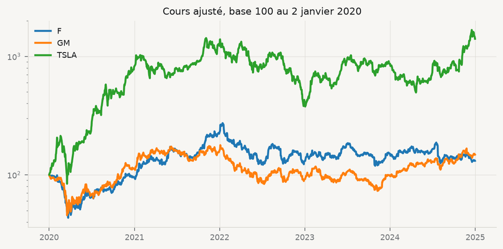

```python
from plotstyle import setup
plt = setup()

base100 = prix / prix.iloc[0] * 100
fig, ax = plt.subplots()
for ticker in base100.columns:
    ax.plot(base100.index, base100[ticker], label=ticker)
ax.set_yscale("log")
ax.set_title("Cours ajusté, base 100 au 2 janvier 2020")
ax.legend(frameon=False)
plt.show()
```

## Un mot sur Yahoo Finance

- `yfinance` n’est **pas** un produit officiel de Yahoo : c’est un paquet bénévole qui lit le site. Il casse parfois quand le site change ; `pip install -U yfinance` règle souvent le problème.
- Les conditions d’utilisation de Yahoo **interdisent de redistribuer** les données : on les télécharge, on ne les publie pas dans le dépôt.
- Pour un travail de recherche, les sources de référence sont CRSP ou Compustat via **WRDS**, auxquelles HEC Montréal donne accès.

## `wbgapi` : la Banque mondiale en une ligne

```python
import wbgapi as wb

co2_hab = charger("wb_co2_hab", lambda: wb.data.DataFrame(
    "EN.GHG.CO2.PC.CE.AR5",                       # CO₂ par habitant, tonnes
    ["USA", "CAN", "CHN", "NOR", "DEU"],
    time=range(2018, 2023)).reset_index())
co2_hab
```

|  | economy | YR2018 | YR2019 | YR2020 | YR2021 | YR2022 |
| --- | --- | --- | --- | --- | --- | --- |
| 0 | CAN | 16.523882 | 16.190860 | 14.421905 | 14.689759 | 14.783909 |
| 1 | CHN | 8.217736 | 8.391476 | 8.478583 | 8.887157 | 8.864825 |
| 2 | DEU | 9.006578 | 8.382180 | 7.721033 | 8.061281 | 7.911829 |
| 3 | NOR | 8.780335 | 8.479335 | 8.124938 | 8.214714 | 7.979858 |
| 4 | USA | 15.579646 | 15.043966 | 13.471567 | 14.316098 | 14.418622 |

Comment connaître le code `EN.GHG.CO2.PC.CE.AR5` ? `wb.series.info(q="CO2")` cherche dans les quelque 1 500 indicateurs du catalogue.

# Les API

## Une API, c’est une URL qui répond avec des données

```
https://api.worldbank.org/v2/country/CAN;USA;CHN/indicator/EG.ELC.RNEW.ZS?format=json&date=2015:2022
└──────── serveur ──────┘└──── ressource : quels pays, quel indicateur ───┘└──── paramètres ────┘
```

| Élément | Rôle |
| --- | --- |
| **Point d’accès** (*endpoint*) | L’adresse de la ressource |
| **Paramètres** | Ce qu’on filtre : années, format, taille de page |
| **En-têtes** (*headers*) | Qui demande : `User-Agent`, clé d’accès |
| **Code de statut** | `200` = OK, `404` = introuvable, `429` = trop de requêtes, `403` = refusé |
| **Réponse** | Le plus souvent du **JSON** : listes et dictionnaires imbriqués |

## `requests.get` : la requête

```python
import requests

url = "https://api.worldbank.org/v2/country/CAN;USA;CHN;NOR;POL/indicator/EG.ELC.RNEW.ZS"
parametres = {"format": "json", "date": "2015:2022", "per_page": 100}

reponse = requests.get(url, params=parametres, timeout=30)
print(reponse.status_code)
print(reponse.url)
```

```
200
https://api.worldbank.org/v2/country/CAN;USA;CHN;NOR;POL/indicator/EG.ELC.RNEW.ZS?format=json&date=2015%3A2022&per_page=100
```

`params=` construit la fin de l’URL pour vous, avec les bons `?` et `&`. `timeout=30` évite d’attendre indéfiniment un serveur qui ne répond pas.

## Lire le JSON

```python
donnees = reponse.json()
print(type(donnees), len(donnees))
print(donnees[0])                 # l'en-tête : pages, total
donnees[1][0]                     # la première observation
```

```
<class 'list'> 2
{'page': 1, 'pages': 1, 'per_page': 100, 'total': 40, 'sourceid': '2', 'lastupdated': '2026-10-08'}
```

```
{'indicator': {'id': 'EG.ELC.RNEW.ZS',
  'value': 'Renewable electricity output (% of total electricity output)'},
 'country': {'id': 'CA', 'value': 'Canada'},
 'countryiso3code': 'CAN',
 'date': '2022',
 'value': None,
 'unit': '',
 'obs_status': '',
 'decimal': 2}
```

La Banque mondiale renvoie une **liste de deux éléments** : les métadonnées (`page`, `pages`, `total`), puis la liste des observations. Chaque observation est un dictionnaire, parfois imbriqué.

## Du JSON au DataFrame

```python
lignes = [
    {"iso3": obs["countryiso3code"], "annee": int(obs["date"]), "renouv_pct": obs["value"]}
    for obs in donnees[1]
]
elec = pd.DataFrame(lignes)
elec.pivot(index="annee", columns="iso3", values="renouv_pct").round(1).tail(4)
```

| iso3 annee | CAN | CHN | NOR | POL | USA |
| --- | --- | --- | --- | --- | --- |
| 2019 | 65.9 | 26.9 | 97.8 | 16.0 | 17.9 |
| 2020 | 67.1 | 28.1 | 98.4 | 18.4 | 19.9 |
| 2021 | 67.0 | 28.4 | 99.1 | 17.5 | 20.3 |
| 2022 | NaN | NaN | NaN | NaN | NaN |

Part de l’électricité produite à partir de sources renouvelables (%). Une Tesla au Canada ou en Norvège roule surtout à l’hydroélectricité ; en Pologne ou en Chine, surtout au charbon. La ligne 2022 est vide : la série publiée s’arrête en 2021 — une source a toujours un **retard**.

## La pagination : quand la réponse ne tient pas sur une page

```python
def banque_mondiale(indicateur, pays="all", dates="2015:2022"):
    """Toutes les pages d'un indicateur de la Banque mondiale, dans un DataFrame."""
    url = f"https://api.worldbank.org/v2/country/{pays}/indicator/{indicateur}"
    page, lignes = 1, []
    while True:
        r = requests.get(url, params={"format": "json", "date": dates,
                                      "per_page": 1000, "page": page}, timeout=60)
        r.raise_for_status()                      # stoppe net si le statut n'est pas 200
        meta, obs = r.json()
        lignes += [{"iso3": o["countryiso3code"], "annee": int(o["date"]),
                    "valeur": o["value"]} for o in obs]
        if page >= meta["pages"]:
            return pd.DataFrame(lignes)
        page += 1

tous = charger("wb_renouv_tous", lambda: banque_mondiale("EG.ELC.RNEW.ZS"))
print(tous.shape)
```

```
(2128, 3)
```

## SEC EDGAR : les états financiers déposés

```python
import os

# La SEC exige un User-Agent qui vous identifie : « Prénom Nom courriel ».
# On le lit dans une variable d'environnement, jamais écrit dans le code.
ua = os.environ.get("SEC_USER_AGENT", "HEC Montreal MNGT60439 course")

def faits_tesla():
    url = "https://data.sec.gov/api/xbrl/companyfacts/CIK0001318605.json"
    r = requests.get(url, headers={"User-Agent": ua}, timeout=60)
    r.raise_for_status()
    ventes = r.json()["facts"]["us-gaap"]["RevenueFromContractWithCustomerExcludingAssessedTax"]
    return pd.DataFrame(ventes["units"]["USD"])

brut = charger("sec_tesla_ventes", faits_tesla)
print(brut.shape)
brut[["end", "val", "fy", "form", "frame"]].tail(4)
```

```
(49, 9)
```

|  | end | val | fy | form | frame |
| --- | --- | --- | --- | --- | --- |
| 45 | 2026-06-30 | 50623000000 | 2026 | 10-Q | NaN |
| 46 | 2026-06-30 | 28236000000 | 2026 | 10-Q | CY2026Q2 |
| 47 | 2026-09-30 | 78669000000 | 2026 | 10-Q | NaN |
| 48 | 2026-09-30 | 28046000000 | 2026 | 10-Q | CY2026Q3 |

## Démêler la réponse de la SEC

Une même année de ventes apparaît **plusieurs fois** : dans le rapport annuel de l’année, puis comme point de comparaison dans les deux rapports suivants. Le champ `frame` désigne la valeur retenue pour chaque année civile.

```python
annuel = brut[brut["frame"].fillna("").str.fullmatch(r"CY\d{4}")]
annuel = annuel.assign(annee=annuel["frame"].str[2:].astype(int),
                       ventes_G=annuel["val"] / 1e9)
annuel[["annee", "ventes_G", "form", "end"]].tail(5)
```

|  | annee | ventes_G | form | end |
| --- | --- | --- | --- | --- |
| 6 | 2021 | 53.823 | 10-K | 2021-12-31 |
| 10 | 2022 | 81.462 | 10-K | 2022-12-31 |
| 20 | 2023 | 96.773 | 10-K | 2023-12-31 |
| 32 | 2024 | 97.690 | 10-K | 2024-12-31 |
| 43 | 2025 | 94.827 | 10-K | 2025-12-31 |

C’est exactement ce que fait `scripts/build_course_data.py` pour les 32 entreprises du cours.

## Les règles du jeu d’une API

| Règle | SEC EDGAR | Banque mondiale | FRED (Réserve fédérale) |
| --- | --- | --- | --- |
| Identification | `User-Agent` avec courriel | Aucune | **Clé d’API** gratuite |
| Limite de débit | 10 requêtes / seconde | Raisonnable | 120 requêtes / minute |
| Licence | Domaine public | CC BY 4.0 | Selon la série |

Dépasser la limite donne un code **`429`** ou **`403`**, parfois un blocage de quelques minutes. Dans une boucle, ajoutez `time.sleep(0.2)` entre deux requêtes.

## Une clé d’API ne s’écrit jamais dans le code

```python
import os, requests

cle = os.environ["FRED_API_KEY"]          # définie dans le terminal, pas ici
r = requests.get("https://api.stlouisfed.org/fred/series/observations",
                 params={"series_id": "DCOILWTICO", "api_key": cle, "file_type": "json",
                         "observation_start": "2020-01-01"}, timeout=30)
petrole = pd.DataFrame(r.json()["observations"])[["date", "value"]]
```

```bash
export FRED_API_KEY="votre-cle"            # macOS / Linux (ajoutez-la à ~/.zshrc)
setx FRED_API_KEY "votre-cle"              # Windows (rouvrez le terminal ensuite)
```

Une clé publiée sur GitHub est trouvée par des robots **en quelques minutes**. Si cela arrive : révoquez-la sur le site du fournisseur, puis créez-en une autre. L’effacer du dépôt ne suffit pas.

# Les bases de données

## Pourquoi une base de données ?

| Fichier CSV | Base de données |
| --- | --- |
| Un fichier = une table | Plusieurs tables, reliées par des clés |
| On charge **tout** en mémoire | On demande **seulement** ce qu’il faut |
| Aucun contrôle des types | Chaque colonne a un type |
| Un utilisateur à la fois | Des milliers, en même temps |

Les données des entreprises vivent dans des bases (SAP, Oracle, Snowflake…). On les interroge en **SQL**, un langage que vous retrouverez dans tous les postes d’analyste.

## Se connecter à SQLite

```python
import sqlite3

con = sqlite3.connect("data/strategie.db")
pd.read_sql("SELECT name FROM sqlite_master WHERE type = 'table'", con)
```

|  | name |
| --- | --- |
| 0 | entreprises |
| 1 | pays |
| 2 | secteurs |

SQLite est une base **contenue dans un seul fichier**, livrée avec Python : rien à installer. `data/strategie.db` contient les trois tables du cours.

## `SELECT … FROM … WHERE`

```python
requete = """
SELECT entreprise, annee, chiffre_affaires, resultat_net
FROM entreprises
WHERE secteur = 'Automobile' AND annee >= 2022
ORDER BY annee, chiffre_affaires DESC
"""
pd.read_sql(requete, con)
```

|  | entreprise | annee | chiffre_affaires | resultat_net |
| --- | --- | --- | --- | --- |
| 0 | Ford | 2022 | 158057.0 | -1981.0 |
| 1 | General Motors | 2022 | 143975.0 | 9708.0 |
| 2 | Tesla | 2022 | 81462.0 | 12587.0 |
| 3 | Ford | 2023 | 176191.0 | 4347.0 |
| 4 | General Motors | 2023 | 157658.0 | 9840.0 |
| 5 | Tesla | 2023 | 96773.0 | 14974.0 |
| 6 | Ford | 2024 | 184992.0 | 5879.0 |
| 7 | General Motors | 2024 | 171606.0 | 5963.0 |
| 8 | Tesla | 2024 | 97690.0 | 7153.0 |

`SELECT` choisit les colonnes, `FROM` la table, `WHERE` les lignes, `ORDER BY` l’ordre. Le résultat arrive directement dans un DataFrame.

## `GROUP BY` : agréger dans la base

```python
pd.read_sql("""
SELECT secteur,
       COUNT(DISTINCT ticker)               AS n_entreprises,
       ROUND(SUM(chiffre_affaires) / 1000, 1) AS ventes_milliards,
       ROUND(AVG(resultat_net * 1.0 / chiffre_affaires) * 100, 1) AS marge_moy_pct
FROM entreprises
WHERE annee = 2023
GROUP BY secteur
ORDER BY ventes_milliards DESC
""", con)
```

|  | secteur | n_entreprises | ventes_milliards | marge_moy_pct |
| --- | --- | --- | --- | --- |
| 0 | Commerce de détail | 4 | 1567.1 | 3.5 |
| 1 | Technologie | 7 | 1214.5 | 25.2 |
| 2 | Énergie | 3 | 590.0 | 14.6 |
| 3 | Automobile | 3 | 430.6 | 8.1 |
| 4 | Biens de consommation | 4 | 270.6 | 15.6 |
| 5 | Pharmaceutique | 4 | 230.3 | 15.4 |
| 6 | Industrie | 4 | 202.5 | 0.3 |
| 7 | Restauration | 2 | 61.5 | 22.3 |
| 8 | Médias et divertissement | 1 | 33.7 | 16.0 |

## `JOIN` : relier deux tables

```python
pd.read_sql("""
SELECT e.entreprise, e.annee, e.chiffre_affaires,
       p.pib_milliards_usd,
       ROUND(e.chiffre_affaires / 1000 / p.pib_milliards_usd * 100, 2) AS ventes_pct_pib_usa
FROM entreprises AS e
JOIN pays AS p ON p.iso3 = e.pays_siege AND p.annee = e.annee
WHERE e.ticker IN ('TSLA', 'WMT', 'AAPL') AND e.annee = 2023
""", con)
```

|  | entreprise | annee | chiffre_affaires | pib_milliards_usd | ventes_pct_pib_usa |
| --- | --- | --- | --- | --- | --- |
| 0 | Tesla | 2023 | 96773.0 | 27811.52 | 0.35 |
| 1 | Apple | 2023 | 383285.0 | 27811.52 | 1.38 |
| 2 | Walmart | 2023 | 642637.0 | 27811.52 | 2.31 |

La **clé** relie les tables : ici le pays du siège (`USA`) et l’année. Walmart vend l’équivalent d’environ 2 % du PIB américain — une comparaison grossière (ventes ≠ valeur ajoutée), mais parlante.

## Paramètres : ne jamais coller du texte dans une requête

```python
secteur_choisi = "Énergie"
pd.read_sql("SELECT entreprise, annee, resultat_net FROM entreprises "
            "WHERE secteur = ? AND annee = ?", con, params=(secteur_choisi, 2023))
```

|  | entreprise | annee | resultat_net |
| --- | --- | --- | --- |
| 0 | ExxonMobil | 2023 | 36010.0 |
| 1 | Chevron | 2023 | 21400.0 |
| 2 | ConocoPhillips | 2023 | 10957.0 |

Le `?` est rempli par `params=`. Construire la requête avec `f"... '{secteur_choisi}'"` casse dès qu’un nom contient une apostrophe (« McDonald’s ») — et ouvre la porte à l’injection SQL.

```python
con.close()
```

## DuckDB : du SQL directement sur un fichier

```python
import duckdb

duckdb.sql("""
SELECT ticker, chiffre_affaires, resultat_net
FROM 'data/entreprises.csv'
WHERE annee = 2024
ORDER BY chiffre_affaires DESC
LIMIT 5
""").df()
```

|  | ticker | chiffre_affaires | resultat_net |
| --- | --- | --- | --- |
| 0 | WMT | 674538.0 | 19436.0 |
| 1 | AMZN | 637959.0 | 59248.0 |
| 2 | AAPL | 391035.0 | 93736.0 |
| 3 | GOOGL | 350018.0 | 100118.0 |
| 4 | XOM | 349585.0 | 33680.0 |

Aucune base à créer : DuckDB lit le CSV (ou un fichier parquet) **comme une table**. Sur de gros fichiers, il est souvent bien plus rapide que pandas.

# Sauvegarder, mettre en cache, documenter

## CSV ou parquet ?

```python
co2.to_csv("sorties/co2.csv", index=False)
co2.to_parquet("sorties/co2.parquet")

for f in ["sorties/co2.csv", "sorties/co2.parquet"]:
    print(f"{f:22s} {Path(f).stat().st_size / 1e6:5.2f} Mo")
```

```
sorties/co2.csv         1.36 Mo
sorties/co2.parquet     0.17 Mo
```

|  | CSV | Parquet |
| --- | --- | --- |
| Lisible par un humain, par Excel | Oui | Non |
| Conserve les types (dates, catégories) | Non | Oui |
| Taille, vitesse | Grand, lent | Compact, rapide |

**Règle du cours :** parquet pour vos copies de travail, CSV pour ce que vous remettez.

## Ce que vous avez dans le cache

```python
for f in sorted(CACHE.glob("*.parquet")):
    print(f"{f.name:28s} {pd.read_parquet(f).shape}")
```

```
AMZN.parquet                 (651, 5)
CVX.parquet                  (651, 5)
INTC.parquet                 (651, 5)
JNJ.parquet                  (651, 5)
MRK.parquet                  (651, 5)
MSFT.parquet                 (651, 5)
PFE.parquet                  (651, 5)
SPY.parquet                  (651, 5)
XOM.parquet                  (651, 5)
cours_auto.parquet           (1258, 3)
owid_co2.parquet             (50411, 5)
sec_tesla_ventes.parquet     (49, 9)
wb_co2_hab.parquet           (5, 6)
wb_renouv_5pays.parquet      (45, 3)
wb_renouv_tous.parquet       (2128, 3)
wiki_constructeurs.parquet   (50, 5)
```

Supprimez `data/cache/` et tout se retélécharge. Ce dossier **n’est pas versionné** : chacun reconstruit le sien à partir du code — c’est cela, la reproductibilité.

## La fiche de provenance

Pour chaque source du dossier, une ligne :

| Donnée | Producteur | Accès | Date d’accès | Unité | Licence |
| --- | --- | --- | --- | --- | --- |
| Ventes, résultat | SEC EDGAR | API `companyfacts` | 2026-11-06 | M$ US courants | Domaine public |
| CO₂ par habitant | Global Carbon Project via OWID | URL CSV | 2026-11-06 | t CO₂ / hab. | CC BY 4.0 |
| Électricité renouvelable | Banque mondiale | API v2 | 2026-11-06 | % de la production | CC BY 4.0 |
| Cours boursiers | Yahoo Finance | `yfinance` | 2026-11-06 | $ US ajustés | Usage personnel |

Votre rapport final en contiendra une. Commencez-la aujourd’hui : dans six semaines, vous ne saurez plus d’où vient le fichier `donnees_v3_final.csv`.

## Avant la pratique

- `data/cache/` contient vos copies : la pratique peut se faire **sans réseau**
- Votre `SEC_USER_AGENT` est défini (`echo $SEC_USER_AGENT` l’affiche)
- `pd.read_csv` sur une URL fonctionne — sinon, le correctif des certificats

**Pratique :** *Monter le dossier de données « Tesla et l’environnement », de cinq sources, avec sa fiche de provenance.*